# Machine Learning / Aprendizagem Automática

## 2.2. Learning and Evaluating Clusterings

In this section, unsupervised learning is applied to the **PetFinder dataset** using **KMeans clustering**. The objective is to identify distinct groups of pets based on their characteristics, without using any labeled data (i.e., no adoption speed or outcome is used during clustering).

1. **Data Preprocessing**:
   - Irrelevant columns (such as `PetID`, `RescuerID`, etc.) are removed to focus on the features related to pet characteristics.
   - **Categorical variables** are processed using **Label Encoding** for ordinal variables (e.g., `MaturitySize`, `FurLength`) and **One-Hot Encoding** for nominal variables (e.g., `Gender`, `Color1`, `State`).
   - The dataset is then **standardized** using `StandardScaler` to normalize the feature values, which is essential for clustering.
2. **Feature Selection**:
   - A subset of relevant features, such as `Age`, `Health`, `Fee`, and `Quantity`, is selected for clustering, as these are expected to influence the pet's characteristics and potential adoption speed.
3. **KMeans Clustering**:
   - **KMeans** is used to cluster the pets into 4 groups. The number of clusters (`n_clusters=4`) is chosen based on an assumption of potential groupings within the data, but this could be adjusted based on further analysis.
   - The **cluster labels** are then added to the data, allowing each pet to be assigned to one of the 4 clusters.
4. **Evaluation**:
   - The clustering performance is assessed using the **Silhouette Score**, which measures how similar each pet is to its own cluster compared to other clusters. A higher score indicates better-defined clusters.
5. **Visualization**:
   - **PCA (Principal Component Analysis)** is used to reduce the dimensionality of the data to 2 components for easy visualization in a 2D space.
   - A scatter plot is created to visualize how the pets are grouped into clusters based on their characteristics.
6. **Cluster Analysis**:
   - The mean values of the selected features are computed for each cluster to explore the characteristics that define each group (e.g., one cluster might have pets with higher health, while another cluster might have younger pets).

The goal of this clustering approach is to uncover hidden patterns in the pet characteristics, which might suggest natural groupings related to pet types, health, age, and adoption potential.

```
Silhouette Score: 0.2486
```

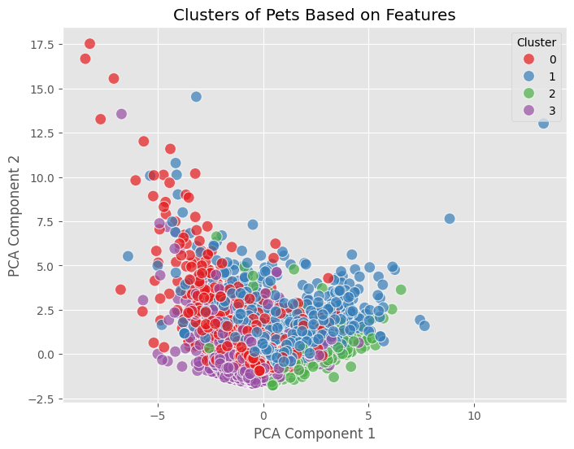

```
Cluster Characteristics:
               Age  MaturitySize  FurLength    Health        Fee  Quantity  \
Cluster
0         8.704376      1.090161   0.000155  0.000000  14.666667  1.581316
1        12.709658      1.095581   1.153569  0.000000  31.298740  1.517497
2        20.376699      0.815534   0.570874  1.066019  17.881553  1.304854
3         8.757666      0.000000   0.311573  0.000000  19.289482  1.707550

         PhotoAmt  VideoAmt
Cluster
0        4.048262  0.067194
1        3.816437  0.048990
2        3.396117  0.050485
3        3.755028  0.048467
```

```python
df = pd.read_csv('PetFinder_dataset.csv')


# Preprocess the data (similar to previous steps)
def preprocess_data_for_clustering(df):
    # Drop irrelevant columns
    df_cleaned = df.drop(columns=['PetID', 'RescuerID', 'Name', 'Description'])

    # Convert categorical columns to category type
    categorical_columns = ['Type', 'Gender', 'Color1', 'Color2', 'Color3', 'MaturitySize',
                           'FurLength', 'Vaccinated', 'Dewormed', 'Sterilized', 'Health', 'State']

    for col in categorical_columns:
        df_cleaned[col] = df_cleaned[col].astype('category')

    # Label encode the ordinal categorical columns
    label_columns = ['MaturitySize', 'FurLength', 'Vaccinated', 'Dewormed', 'Sterilized', 'Health']
    label_encoder = LabelEncoder()
    for col in label_columns:
        df_cleaned[col] = label_encoder.fit_transform(df_cleaned[col])

    # One-Hot Encoding for nominal categorical columns (e.g., 'Type', 'Gender', 'Color1', etc.)
    df_cleaned = pd.get_dummies(df_cleaned, columns=['Gender', 'Color1', 'Color2', 'Color3', 'State', 'Type'], drop_first=True)

    return df_cleaned

# Preprocess the data
data_cleaned = preprocess_data_for_clustering(df)

# Select the relevant features for clustering
features = ['Age', 'MaturitySize', 'FurLength', 'Health', 'Fee', 'Quantity', 'PhotoAmt', 'VideoAmt']
X = data_cleaned[features]

# Standardize the data before clustering (important for distance-based models)
scaler = StandardScaler()
X_scaled = scaler.fit_transform(X)

# Apply KMeans clustering
kmeans = KMeans(n_clusters=4, random_state=42)
kmeans.fit(X_scaled)

# Add the cluster labels to the data
data_cleaned['Cluster'] = kmeans.labels_

# Evaluate clustering using silhouette score
silhouette_avg = silhouette_score(X_scaled, kmeans.labels_)
print(f'Silhouette Score: {silhouette_avg:.4f}')

# Visualize the clusters using PCA for dimensionality reduction (2D visualization)
pca = PCA(n_components=2)
X_pca = pca.fit_transform(X_scaled)

# Create a scatter plot of the clusters
plt.figure(figsize=(8, 6))
sns.scatterplot(x=X_pca[:, 0], y=X_pca[:, 1], hue=data_cleaned['Cluster'], palette='Set1', s=100, alpha=0.7)
plt.title('Clusters of Pets Based on Features')
plt.xlabel('PCA Component 1')
plt.ylabel('PCA Component 2')
plt.legend(title='Cluster')
plt.show()

# Cluster analysis: Explore the characteristics of each cluster
cluster_summary = data_cleaned.groupby('Cluster')[features].mean()
print("\nCluster Characteristics:")
print(cluster_summary)
```

## 2.3. Clustering - Final Discussion and Conclusions

### Brief Description for Clustering and Cluster Characterization

This section applies **KMeans clustering** to group pets based on selected numerical features like age, health, sterilization, and adoption fee.

- **Clustering**: Pets are clustered into 5 groups using KMeans.
- **Cluster Labels**: Each pet is assigned a cluster label.
- **Cluster Characterization**: The average values of features for each cluster are computed to understand group characteristics.
- **Visualization**: A heatmap is used to visualize the feature averages for each cluster.

This helps identify patterns in the dataset, such as clusters of pets with similar attributes.

```
               Age  MaturitySize  FurLength  Vaccinated  Dewormed  Sterilized  \
Cluster
0         9.974167      0.854835   0.437552    0.767203  0.595138    0.934314
1        21.816254      0.939929   0.901060    0.328622  0.272085    0.699647
2        10.033719      0.910405   0.510597    0.539499  0.332370    0.818882
3        12.384615      1.179487   1.333333    0.487179  0.205128    1.051282
4        17.147059      0.880392   0.843137    0.437255  0.268627    0.700000

           Health         Fee  Quantity
Cluster
0        0.038025    0.566486  1.612512
1        0.035336  372.268551  1.134276
2        0.022158   74.052987  1.419075
3        0.025641  795.820513  1.205128
4        0.031373  192.276471  1.231373
```

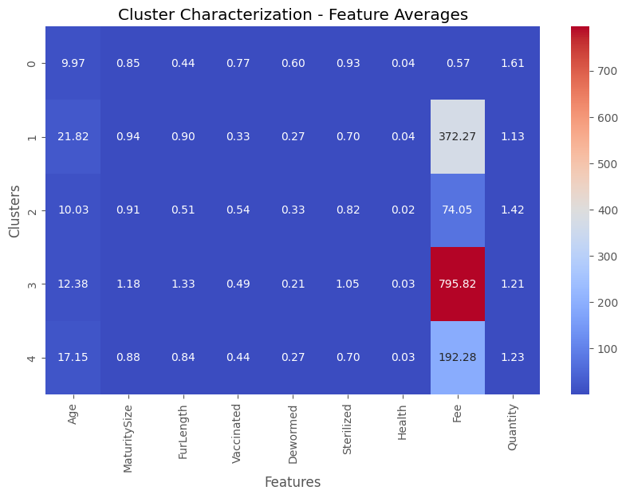

```python
# For the sake of simplicity, let's assume you want to cluster on the numerical features only
numerical_features = ['Age', 'MaturitySize', 'FurLength', 'Vaccinated', 'Dewormed', 'Sterilized', 'Health', 'Fee', 'Quantity']

X = data_cleaned[numerical_features]  # Data for clustering

# Step 1: Perform Clustering with KMeans
kmeans = KMeans(n_clusters=5, random_state=42)  # Choosing 5 clusters for illustration
cluster_labels = kmeans.fit_predict(X)  # This gives the cluster assignments for each data point

# Step 2: Add the cluster labels to the original dataset
data_cleaned['Cluster'] = cluster_labels

# Step 3: Characterize the clusters by calculating the mean of features for each cluster
cluster_characteristics = data_cleaned.groupby('Cluster')[numerical_features].mean()

# Print the cluster characteristics
print(cluster_characteristics)


plt.figure(figsize=(10, 6))
sns.heatmap(cluster_characteristics, annot=True, cmap='coolwarm', fmt='.2f')
plt.title('Cluster Characterization - Feature Averages')
plt.xlabel('Features')
plt.ylabel('Clusters')
plt.show()
```

## 3. Final Comments and Conclusions

In this project, we performed both **supervised** and **unsupervised** learning to analyze the PetFinder dataset. Here's a summary of the findings:

1. **Binary and Multiclass Classification**:
   - We trained multiple classification models (e.g., Decision Tree, Random Forest, Logistic Regression, SVM, Naive Bayes) to predict adoption outcomes for pets.
   - For **binary classification** (adopted vs. not adopted), we observed how different models performed, focusing on precision, recall, and accuracy.
   - For **multiclass classification** (predicting adoption speed), the models were evaluated for their ability to categorize pets into adoption speed classes, with confusion matrices and classification reports aiding performance evaluation.
2. **Clustering**:
   - Using **KMeans clustering**, we grouped pets based on features like age, health, and adoption fee.
   - We identified 5 clusters that helped characterize pets with similar attributes, which could assist in targeting adoption strategies or understanding common traits in adopted vs. non-adopted pets.
3. **Insights**:
   - The clustering results gave valuable insights into the types of pets that could be grouped together, based on their attributes. For example, pets with higher adoption fees and specific health conditions formed distinct groups.
   - The classification models provided a way to predict adoption likelihood, offering useful information for future adoption efforts.
4. **Future Work**:
   - Incorporating additional data (e.g., pet photos, owner details) might improve predictive accuracy.
   - More advanced techniques like **ensemble methods** or **deep learning** could also be explored to enhance model performance.
   - Clustering could be further refined by experimenting with different numbers of clusters or exploring hierarchical clustering techniques.

In conclusion, this analysis offers a comprehensive approach to understanding pet adoption patterns, with both predictive and exploratory insights.